# Practical Machine Learning Project Report

by Leykun Getaneh

## Introduction

Using devices such as Jawbone Up, Nike FuelBand, and Fitbit it is now possible to collect a large amount of data about personal activity relatively inexpensively. These type of devices are part of the quantified self movement - a group of enthusiasts who take measurements about themselves regularly to improve their health, to find patterns in their behavior, or because they are tech geeks. One thing that people regularly do is quantify how much of a particular activity they do, but they rarely quantify how well they do it.

In this project, we will use data from accelerometers on the belt, forearm, arm, and dumbell of 6 participants to predict the manner in which they did the exercise.

## Data Preprocessing

```r
library(knitr)
library(caret)
```

```r
library(rpart)
library(rpart.plot)
library(rattle)
library(randomForest)
library(corrplot)
```

### Read the Data

After downloading the data from the data source, we can read the two csv files into two data frames.

```r
training <- read.csv("./data/pml-training.csv")
testing <- read.csv("./data/pml-testing.csv")
dim(training)
```

```
## [1] 19622   160
```

```r
dim(testing)
```

```
## [1]  20 160
```

The training data set contains 19622 observations and 160 variables, while the testing data set contains 20 observations and 160 variables. The “classe” variable in the training set is the outcome to predict.

### Clean the data

In this step, we will clean the data and get rid of observations with missing values as well as some meaningless variables.

First, we remove columns that contain NA missing values.

```r
training <- training[, colSums(is.na(training)) == 0]
testing <- testing[, colSums(is.na(testing)) == 0]
dim(training)
```

```
## [1] 19622    93
```

```r
dim(testing)
```

```
## [1] 20 60
```

Next, we get rid of some columns that do not contribute much to the accelerometer measurements.

```r
classe <- training$classe
trainRemove <- grepl("^X|timestamp|window", names(training))
training <- training[, !trainRemove]
training <- training[, sapply(training, is.numeric)]
training$classe <- classe
testRemove <- grepl("^X|timestamp|window", names(testing))
testing <- testing[, !testRemove]
testing <- testing[, sapply(testing, is.numeric)]
dim(training); dim(testing)
```

```
## [1] 19622    53
```

```
## [1] 20 53
```

Now, the cleaned training data set contains 19622 observations and 53 variables, while the testing data set contains 20 observations and 53 variables. The “classe” variable is still in the cleaned training set.

### Slice the data

Then, we can split the cleaned training set into a pure training data set (70%) and a validation data set (30%). We will use the validation data set to conduct cross validation in future steps.

```r
set.seed(12345) # For reproducibile purpose
inTrain <- createDataPartition(training$classe, p=0.70, list=F)
TrainSet <- training[inTrain, ]
TestSet <- training[-inTrain, ]
```

**Correlation Matrix Visualization** *

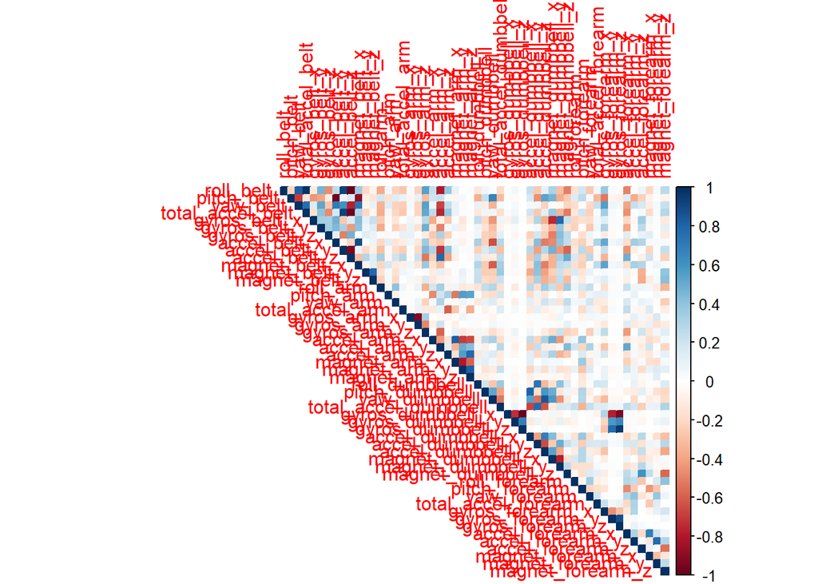

```r
corrPlot <- cor(TrainSet[, -length(names(TrainSet))])
corrplot(corrPlot, method="color", type = "upper")
```

In the corrplot graph the correlated predictors (variables ) are those with a dark color intersection.

## Model building

For this project we will use three different algorithms, classification trees and random forests and Generalized Boosted Model to predict the outcome.

1. classification trees
2. random forests
3. Generalized Boosted Model

### 1. classification trees

We first obtail the model, and then we use the fancyRpartPlot() function to plot the classification tree as a dendogram.

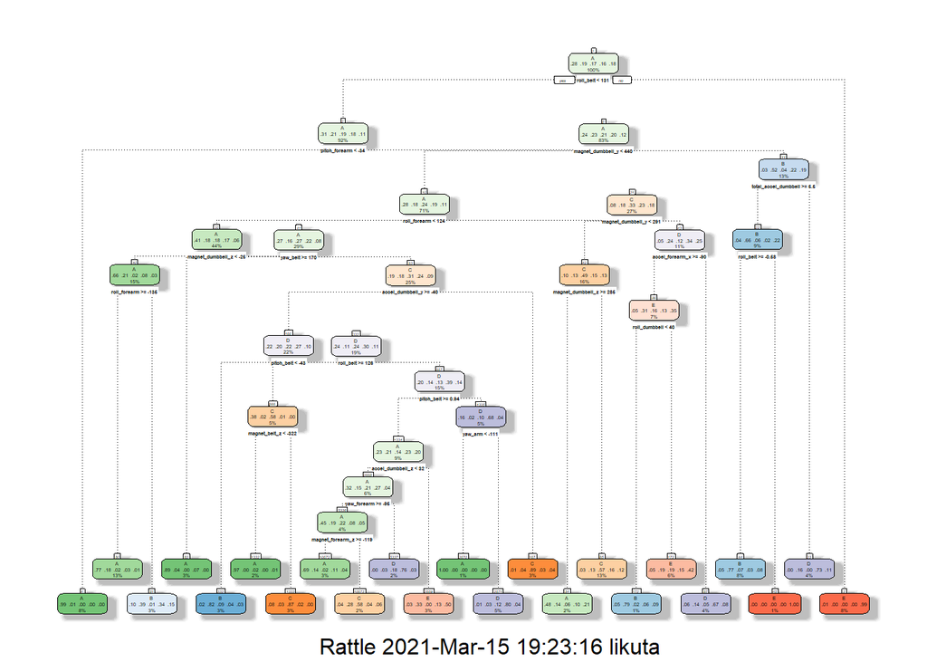

```r
set.seed(12345)
decisionTreeFit <- rpart(classe ~ ., data=TrainSet, method="class")
fancyRpartPlot(decisionTreeFit)
```

```r
TestSet$classe <- as.factor(TestSet$classe)
predictTreeFit <- predict(decisionTreeFit, TestSet, type = "class")
cmtree <- confusionMatrix(predictTreeFit, TestSet$classe)
cmtree
```

```
## Confusion Matrix and Statistics
##
##           Reference
## Prediction    A    B    C    D    E
##          A 1532  176   28   48   41
##          B   54  585   57   64   76
##          C   35  154  819  134  126
##          D   25   76   58  631   56
##          E   28  148   64   87  783
##
## Overall Statistics
##
##                Accuracy : 0.7392
##                  95% CI : (0.7277, 0.7503)
##     No Information Rate : 0.2845
##     P-Value [Acc > NIR] : < 2.2e-16
##
##                   Kappa : 0.6692
##
##  Mcnemar's Test P-Value : < 2.2e-16
##
## Statistics by Class:
##
##                      Class: A Class: B Class: C Class: D Class: E
## Sensitivity            0.9152  0.51361   0.7982   0.6546   0.7237
## Specificity            0.9304  0.94711   0.9076   0.9563   0.9319
## Pos Pred Value         0.8395  0.69976   0.6459   0.7459   0.7054
## Neg Pred Value         0.9650  0.89028   0.9552   0.9339   0.9374
## Prevalence             0.2845  0.19354   0.1743   0.1638   0.1839
## Detection Rate         0.2603  0.09941   0.1392   0.1072   0.1331
## Detection Prevalence   0.3101  0.14206   0.2155   0.1438   0.1886
## Balanced Accuracy      0.9228  0.73036   0.8529   0.8054   0.8278
```

We see that the accuracy rate of the model is low: 0.7392 and therefore the out-of-sample-error is about 0.26 which is considerable.

### 2. Random Forest

We first determine the model

```r
controlRF <- trainControl(method="cv", number=3, verboseIter=FALSE)
modRF1 <- train(classe ~ ., data=TrainSet, method="rf", trControl=controlRF)
modRF1$finalModel
```

```
##
## Call:
##  randomForest(x = x, y = y, mtry = param$mtry)
##                Type of random forest: classification
##                      Number of trees: 500
## No. of variables tried at each split: 27
##
##         OOB estimate of  error rate: 0.68%
## Confusion matrix:
##      A    B    C    D    E class.error
## A 3899    4    1    0    2 0.001792115
## B   21 2630    7    0    0 0.010534236
## C    0   17 2372    7    0 0.010016694
## D    1    1   18 2230    2 0.009769094
## E    0    2    5    5 2513 0.004752475
```

We then validate the model obtained model `modRF1` on the test data to find out how well it performs by looking at the Accuracy variable

```r
predictRF1 <- predict(modRF1, newdata=TestSet)
cmrf <- confusionMatrix(predictRF1, TestSet$classe)
cmrf
```

```
## Confusion Matrix and Statistics
##
##           Reference
## Prediction    A    B    C    D    E
##          A 1672    7    0    0    0
##          B    1 1128    6    0    0
##          C    1    3 1017    7    1
##          D    0    1    3  956    1
##          E    0    0    0    1 1080
##
## Overall Statistics
##
##                Accuracy : 0.9946
##                  95% CI : (0.9923, 0.9963)
##     No Information Rate : 0.2845
##     P-Value [Acc > NIR] : < 2.2e-16
##
##                   Kappa : 0.9931
##
##  Mcnemar's Test P-Value : NA
##
## Statistics by Class:
##
##                      Class: A Class: B Class: C Class: D Class: E
## Sensitivity            0.9988   0.9903   0.9912   0.9917   0.9982
## Specificity            0.9983   0.9985   0.9975   0.9990   0.9998
## Pos Pred Value         0.9958   0.9938   0.9883   0.9948   0.9991
## Neg Pred Value         0.9995   0.9977   0.9981   0.9984   0.9996
## Prevalence             0.2845   0.1935   0.1743   0.1638   0.1839
## Detection Rate         0.2841   0.1917   0.1728   0.1624   0.1835
## Detection Prevalence   0.2853   0.1929   0.1749   0.1633   0.1837
## Balanced Accuracy      0.9986   0.9944   0.9944   0.9953   0.9990
```

The accuracy rate using the random forest is very high: Accuracy : 0.9946 and therefore the out-of-sample-error is equal to 0.0054

### 3. Generalized Boosted Regression Models

```r
set.seed(12345)
controlGBM <- trainControl(method = "repeatedcv", number = 5, repeats = 1)
modGBM  <- train(classe ~ ., data=TrainSet, method = "gbm", trControl = controlGBM, verbose = FALSE)
```

next, we validate the GBM model

```r
predictGBM <- predict(modGBM, newdata=TestSet)
cmGBM <- confusionMatrix(predictGBM, TestSet$classe)
cmGBM
```

```
## Confusion Matrix and Statistics
##
##           Reference
## Prediction    A    B    C    D    E
##          A 1647   39    0    1    1
##          B   19 1066   38    4   14
##          C    4   33  979   38    6
##          D    4    0    8  915    8
##          E    0    1    1    6 1053
##
## Overall Statistics
##
##                Accuracy : 0.9618
##                  95% CI : (0.9565, 0.9665)
##     No Information Rate : 0.2845
##     P-Value [Acc > NIR] : < 2.2e-16
##
##                   Kappa : 0.9516
##
##  Mcnemar's Test P-Value : 8.329e-08
##
## Statistics by Class:
##
##                      Class: A Class: B Class: C Class: D Class: E
## Sensitivity            0.9839   0.9359   0.9542   0.9492   0.9732
## Specificity            0.9903   0.9842   0.9833   0.9959   0.9983
## Pos Pred Value         0.9757   0.9343   0.9236   0.9786   0.9925
## Neg Pred Value         0.9936   0.9846   0.9903   0.9901   0.9940
## Prevalence             0.2845   0.1935   0.1743   0.1638   0.1839
## Detection Rate         0.2799   0.1811   0.1664   0.1555   0.1789
## Detection Prevalence   0.2868   0.1939   0.1801   0.1589   0.1803
## Balanced Accuracy      0.9871   0.9601   0.9688   0.9726   0.9858
```

### Model Comparison

By comparing the accuracy rate values of the three models, it is clear the the ‘Random Forest’ model is the best model to predict outcome variable. So will use it on the validation data

```r
results <- predict(modRF1, newdata=testing)
results
```

```
##  [1] B A B A A E D B A A B C B A E E A B B B
## Levels: A B C D E
```